# Introduction to Data Visualization with R - AcqVA Aurora workshop

## Bar Chart

One categorical variable.

Generate basic plot

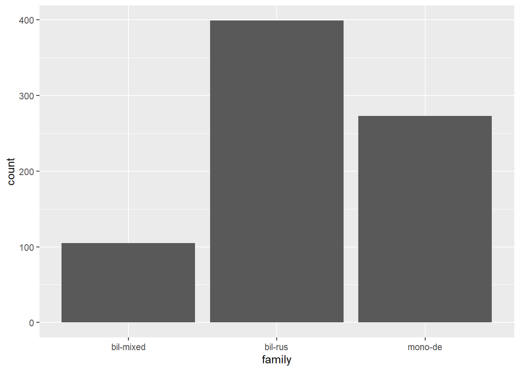

```r
ggplot(myxlsx, aes(x = family)) +
  geom_bar(stat = "count")
```

Alternative: show pre-calculated frequencies

Prepare data

```r
bardata <- myxlsx %>%
  # change the levels of family to be more meaningful
  mutate(family = case_when(family == "bil-mixed" ~ "Mixed bilingual",
                            family == "bil-rus" ~ "Bilingual Russian",
                            family == "mono-de" ~ "Monolingual German",
                            TRUE ~ family)) %>%
  # group by family
  group_by(family) %>%
  # get frequency of familytypes
  summarise(Frequency = n())
# inspect
head(bardata)
```

```
## # A tibble: 3 x 2
##   family             Frequency
##   <chr>                  <int>
## 1 Bilingual Russian        399
## 2 Mixed bilingual          105
## 3 Monolingual German       273
```

- add percentage

```r
bardata <- bardata %>%
  # ungroup
  ungroup() %>%
  # calculate total and stre value in extra column called Total
  mutate(Total = sum(Frequency)) %>%
  # perform calculations row-wise
  rowwise() %>%
  # calculate percent
  mutate(Percent = round(Frequency/Total *100, 1),
         # add a Label column with the Frequency and the Percentage value
         Label = paste0(Frequency, " (", Percent, "%)")) %>%
  # remove Total column (we don't need it any lonnger)
  select(-Total)
# check data
bardata
```

```
## # A tibble: 3 x 4
## # Rowwise:
##   family             Frequency Percent Label
##   <chr>                  <int>   <dbl> <chr>
## 1 Bilingual Russian        399    51.4 399 (51.4%)
## 2 Mixed bilingual          105    13.5 105 (13.5%)
## 3 Monolingual German       273    35.1 273 (35.1%)
```

1 numeric and 1 categorical variable

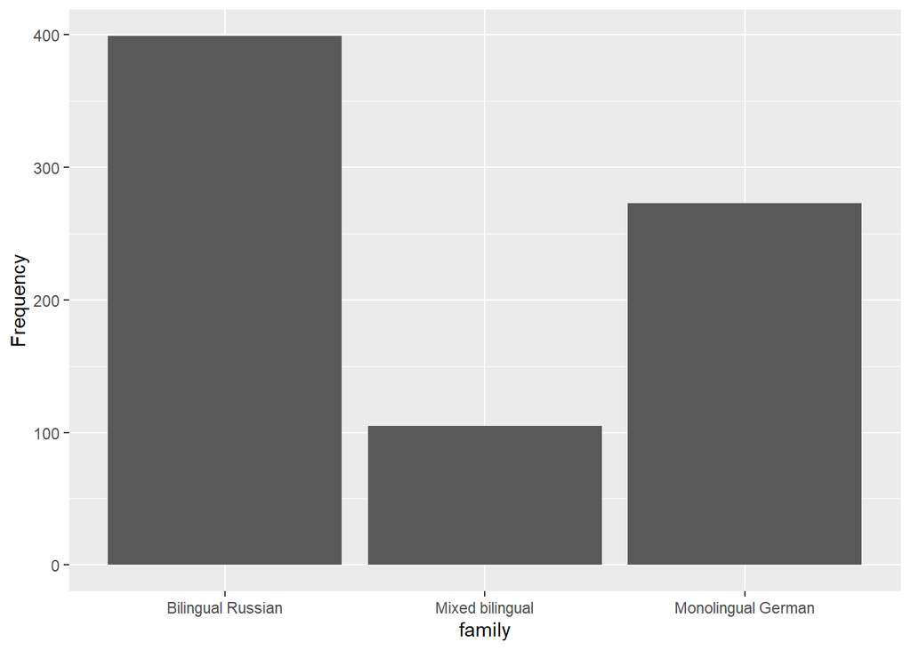

```r
ggplot(bardata, aes(x = family, y = Frequency)) +
  geom_bar(stat = "identity")
```

Prettify plot

- change background
- modify axes labels
- change color/filling
- remove legend

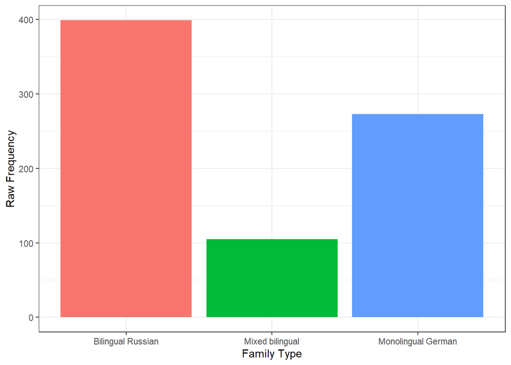

```r
ggplot(bardata, aes(x = family, y = Frequency, fill = family)) +
  geom_bar(stat = "identity") +
  theme_bw() +
  labs(x = "Family Type", y = "Raw Frequency") +
  theme(legend.position = "none")
```

- adapt axis range
- Add text/annotation

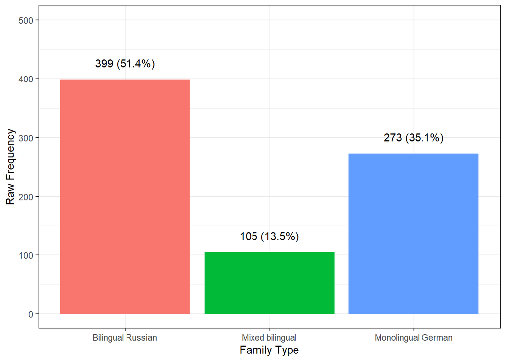

```r
ggplot(bardata, aes(x = family, y = Frequency, fill = family, label = Label)) +
  geom_bar(stat = "identity") +
  theme_bw() +
  labs(x = "Family Type", y = "Raw Frequency") +
  theme(legend.position = "none") +
  coord_cartesian(ylim = c(0, 500)) +
  geom_text(vjust=-1.5, position = position_dodge(0.9))
```

Save plot

```r
ggsave(here::here("images", "nicebar.png"))
```

### Exercise

Use the `regdata` data set (shown below) to create a bargraph that shows the responses by sentence type, word order, and group. Adapt color, axes title, axes tick labels, and try adding text. You can see an example of what the plot looks like below.

```r
regdat <- read.delim(here::here("data", "AJT_V2.csv"), sep = ";") %>%
  # factorize character variables
  dplyr::mutate_if(is.character, factor)
# inspect data
str(regdat)
```

```
## 'data.frame':    2103 obs. of  14 variables:
##  $ ID           : int  3818012 3818012 3818012 3818012 3818012 3818012 3818012 3818012 3818012 3818012 ...
##  $ Version      : int  6 6 6 6 6 6 6 6 6 6 ...
##  $ Task.Name    : Factor w/ 1 level "AJT": 1 1 1 1 1 1 1 1 1 1 ...
##  $ Response     : Factor w/ 2 levels "Bad","Good": 2 2 2 2 2 2 2 1 2 2 ...
##  $ Response_num : int  1 1 1 1 1 1 1 0 1 1 ...
##  $ Sentence     : Factor w/ 24 levels "At 07:00 drenk I wez.",..: 2 1 3 4 6 5 8 7 9 10 ...
##  $ Group        : Factor w/ 2 levels "English","Norwegian-English": 1 1 1 1 1 1 1 1 1 1 ...
##  $ Word_order   : Factor w/ 2 levels "V2","V3": 2 1 2 1 2 1 2 1 2 1 ...
##  $ Num          : int  1 1 2 2 3 3 4 4 5 5 ...
##  $ Sentence_type: Factor w/ 2 levels "Non-subject-initial",..: 1 1 1 1 1 1 1 1 1 1 ...
##  $ Gender       : Factor w/ 2 levels "Female","Male": 1 1 1 1 1 1 1 1 1 1 ...
##  $ Age          : int  42 42 42 42 42 42 42 42 42 42 ...
##  $ Acc          : int  0 1 0 1 0 1 0 0 0 1 ...
##  $ Condition    : Factor w/ 4 levels "AdverbV2","AdverbV3",..: 2 1 2 1 2 1 2 1 2 1 ...
```

You can see an example of what the plot looks like below.

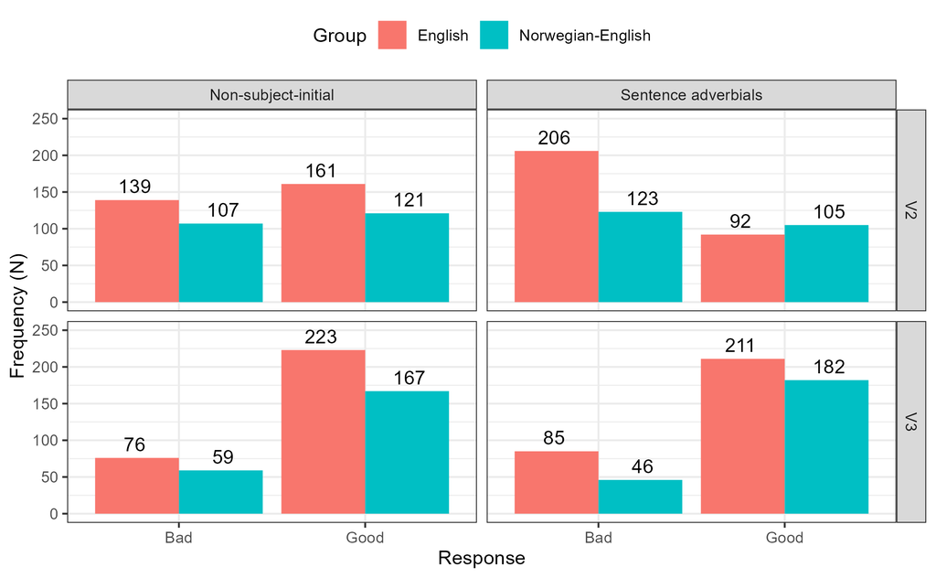

Solution

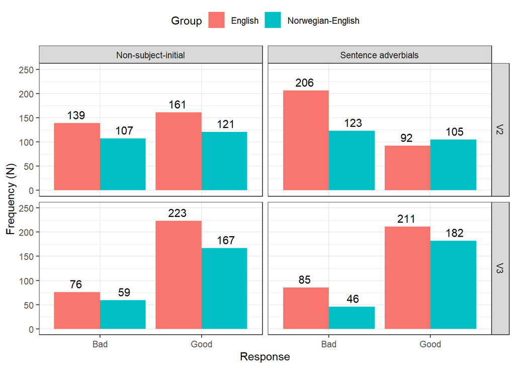

```r
ggplot(regdat, aes(x = Response, fill = Group)) +
  geom_bar(stat = "count", position = position_dodge()) +
  facet_grid(Word_order ~ Sentence_type) +
  theme_bw() +
  labs(y = "Frequency (N)") +
  theme(legend.position = "top") +
  coord_cartesian(ylim = c(0, 250)) +
  geom_text(stat='count',
            aes(label=..count..),
            vjust=-.5,
            position = position_dodge(0.95))
```

## Mosaic plots with vcd

It can be really tricky to visualize several categorical variables simultaneously. As this is quite common, we will now learn to generate *mosaic plots*.

To make the best use of a mosaic plot, we need to create a matrix. But before we can do this, we will transform the data into a tidy format (every observation represents exactly 1 row).

- prepare data: tidy format

```r
mosaicdat <- myxlsx %>%
  # group by family, age_group, and accent_response
  dplyr::group_by(family, age_group, accent_response) %>%
  # get frequencies of the configurations
  dplyr::summarise(Frequency = n())
# inspect
mosaicdat
```

```
## # A tibble: 19 x 4
## # Groups:   family, age_group [7]
##    family    age_group accent_response Frequency
##    <chr>     <chr>     <chr>               <int>
##  1 bil-mixed preschool no                     11
##  2 bil-mixed preschool s                      20
##  3 bil-mixed preschool w                      32
##  4 bil-mixed school    no                      9
##  5 bil-mixed school    s                       2
##  6 bil-mixed school    w                      31
##  7 bil-rus   preschool no                     36
##  8 bil-rus   preschool s                      92
##  9 bil-rus   preschool w                      61
## 10 bil-rus   school    no                     44
## 11 bil-rus   school    s                      53
## 12 bil-rus   school    w                     113
## 13 mono-de   preschool no                    102
## 14 mono-de   preschool s                       1
## 15 mono-de   preschool w                      22
## 16 mono-de   preschool <NA>                    1
## 17 mono-de   school    no                    107
## 18 mono-de   school    w                      19
## 19 mono-de   <NA>      <NA>                   21
```

- ungroup and convert character variables into factors

```r
mosaicdat <- mosaicdat %>%
  # ungroup
  dplyr::ungroup() %>%
  # convert character variables to factors
  dplyr::mutate_if(is.character, factor)
# inspect
mosaicdat
```

```
## # A tibble: 19 x 4
##    family    age_group accent_response Frequency
##    <fct>     <fct>     <fct>               <int>
##  1 bil-mixed preschool no                     11
##  2 bil-mixed preschool s                      20
##  3 bil-mixed preschool w                      32
##  4 bil-mixed school    no                      9
##  5 bil-mixed school    s                       2
##  6 bil-mixed school    w                      31
##  7 bil-rus   preschool no                     36
##  8 bil-rus   preschool s                      92
##  9 bil-rus   preschool w                      61
## 10 bil-rus   school    no                     44
## 11 bil-rus   school    s                      53
## 12 bil-rus   school    w                     113
## 13 mono-de   preschool no                    102
## 14 mono-de   preschool s                       1
## 15 mono-de   preschool w                      22
## 16 mono-de   preschool <NA>                    1
## 17 mono-de   school    no                    107
## 18 mono-de   school    w                      19
## 19 mono-de   <NA>      <NA>                   21
```

- split data (the `pull` function *pulls out* the values for a variable)

```r
mos1 <- mosaicdat %>%
  # filter out all rows where family is bil-mixed
  dplyr::filter(family == "bil-mixed") %>%
  # pull out the numeric values
  dplyr::pull()
# inspect
mos1
```

```
## [1] 11 20 32  9  2 31
```

- we also do this for the other family types

```r
mos2 <- mosaicdat %>%
  dplyr::filter(family == "bil-rus") %>%
  dplyr::pull()
mos3 <- mosaicdat %>%
  dplyr::filter(family == "mono-de") %>%
  dplyr::pull()
# inspect
mos2; mos3
```

```
## [1]  36  92  61  44  53 113
```

```
## [1] 102   1  22   1 107  19  21
```

- generate matrix

```r
# add dimnames (dimension names)
row.names <- c("no", "s", "w")
column.names <- c("preschool", "school")
matrix.names <- c("bil-mixed", "bil-rus", "mono-de")
# generate matrix
mos_mx <- array(c(mos1, mos2, mos3),
                dim = c(3, 2, 3),
                dimnames = list(row.names,
                                column.names,
                                matrix.names))
# inspect
mos_mx
```

```
## , , bil-mixed
##
##    preschool school
## no        11      9
## s         20      2
## w         32     31
##
## , , bil-rus
##
##    preschool school
## no        36     44
## s         92     53
## w         61    113
##
## , , mono-de
##
##    preschool school
## no       102      1
## s          1    107
## w         22     19
```

- basic mosaic plot

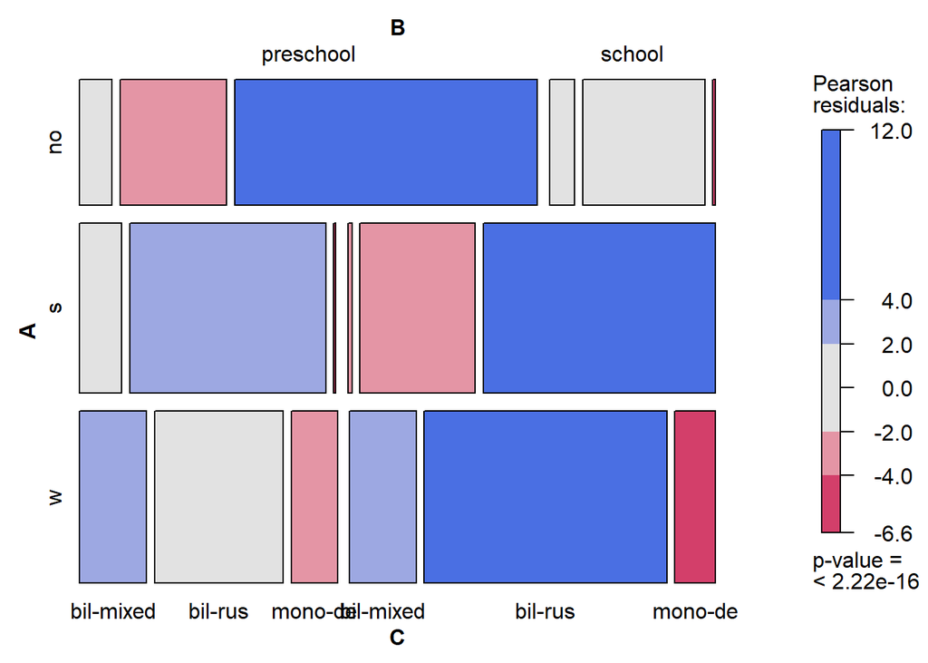

```r
mosaic(mos_mx,
       shade = TRUE,
       direction = c("h",  "v", "v"),
       just_labels = c("center", "center", "center", "center"))
```

- save mosaic plot

```r
# open connection
png(here::here("images", "mosaic.png"), width = 750, height = 300)
# generate plot
mosaic(mos_mx,
       axis.cex = 15,
       shade = TRUE,
       direction = c("h",  "v", "v"),
       just_labels = c("center", "center", "center", "center"))
# close window
dev.off()
```

## Visualizing Likert data

Load data

```r
sdat  <- base::readRDS(url("https://slcladal.github.io/data/sdd.rda", "rb"))
# inspect
head(sdat)
```

```
##    Group Respondent How.did.you.like.the.course. How.did.you.like.the.teacher.
## 1 German         G1                            4                             4
## 2 German         G2                            4                             5
## 3 German         G3                            5                             3
## 4 German         G4                            3                             3
## 5 German         G5                            1                             1
## 6 German         G6                            3                             1
##   Was.the.content.intersting. Was.the.content.adequate.for.the.course.
## 1                           4                                        4
## 2                           3                                        4
## 3                           4                                        2
## 4                           3                                        3
## 5                           1                                        1
## 6                           3                                        2
##   Were.there.enough.discussions. Was.the.use.of.online.materials.appropriate.
```

[output cut: 27 more lines]

- clean column names

```r
# clean column names
colnames(sdat)[3:ncol(sdat)] <- paste0("Q ", str_pad(1:10, 2, "left", "0"), ": ", colnames(sdat)[3:ncol(sdat)]) %>%
  stringr::str_replace_all("\\.", " ") %>%
  stringr::str_squish() %>%
  stringr::str_replace_all("$", "?")
# inspect column names
colnames(sdat)
```

```
##  [1] "Group"
##  [2] "Respondent"
##  [3] "Q 01: How did you like the course?"
##  [4] "Q 02: How did you like the teacher?"
##  [5] "Q 03: Was the content intersting?"
##  [6] "Q 04: Was the content adequate for the course?"
##  [7] "Q 05: Were there enough discussions?"
##  [8] "Q 06: Was the use of online materials appropriate?"
##  [9] "Q 07: Was the teacher appropriately prepared?"
## [10] "Q 08: Was the workload of the course appropriate?"
## [11] "Q 09: Was the course content enganging?"
## [12] "Q 10: Were there enough interactive exerceises included in the sessions?"
```

- replace numeric values with labels

```r
lbs <- c("disagree", "somewhat disagree", "neither agree nor disagree",
         "somewhat agree", "agree")
survey <- sdat %>%
  dplyr::mutate_if(is.character, factor) %>%
  dplyr::mutate_if(is.numeric, factor, levels = 1:5, labels = lbs) %>%
  drop_na() %>%
  as.data.frame()
# inspect
head(survey)
```

```
##    Group Respondent Q 01: How did you like the course?
## 1 German         G1                     somewhat agree
## 2 German         G2                     somewhat agree
## 3 German         G3                              agree
## 4 German         G4         neither agree nor disagree
## 5 German         G5                           disagree
## 6 German         G6         neither agree nor disagree
##   Q 02: How did you like the teacher? Q 03: Was the content intersting?
## 1                      somewhat agree                    somewhat agree
## 2                               agree        neither agree nor disagree
## 3          neither agree nor disagree                    somewhat agree
## 4          neither agree nor disagree        neither agree nor disagree
## 5                            disagree                          disagree
## 6                            disagree        neither agree nor disagree
##   Q 04: Was the content adequate for the course?
```

[output cut: 48 more lines]

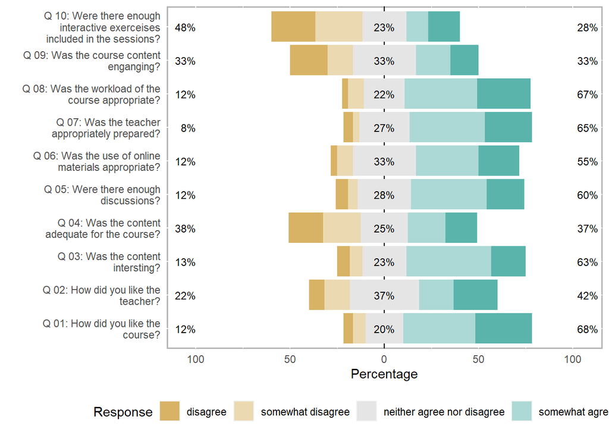

```r
plot(likert(survey[,3:12]), ordered = F, wrap= 30)
```

- save plot

```r
survey_p1 <- plot(likert(survey[,3:12]), ordered = F, wrap= 60)
# save plot
cowplot::save_plot(here("images", "stu_p1.png"), # where to save the plot
                   survey_p1,        # object to plot
                   base_asp = 1.5,  # ratio of space fro questions vs space for plot
                   base_height = 8) # size! higher for smaller font size
```

- include groups

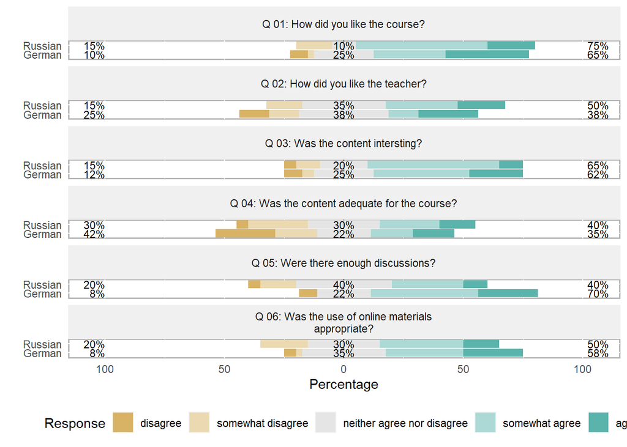

```r
# create plot
survey_p2 <- plot(likert(survey[,3:8], grouping = survey[,1]))
# save plot
cowplot::save_plot(here("images", "stu_p2.png"), # where to save the plot
                   survey_p2,        # object to plot
                   base_asp = 1.5,  # ratio of space fro questions vs space for plot
                   base_height = 8) # size! higher for smaller font size
# show plot
survey_p2
```

# Visualizing Model Effects

- load data

```r
regdat <- read.delim(here::here("data", "AJT_V2.csv"), sep = ";")
# inspect data
str(regdat)
```

```
## 'data.frame':    2103 obs. of  14 variables:
##  $ ID           : int  3818012 3818012 3818012 3818012 3818012 3818012 3818012 3818012 3818012 3818012 ...
##  $ Version      : int  6 6 6 6 6 6 6 6 6 6 ...
##  $ Task.Name    : chr  "AJT" "AJT" "AJT" "AJT" ...
##  $ Response     : chr  "Good" "Good" "Good" "Good" ...
##  $ Response_num : int  1 1 1 1 1 1 1 0 1 1 ...
##  $ Sentence     : chr  "At 07:00 I drenk wez." "At 07:00 drenk I wez." "At 08:00 I woulk the neeb." "At 08:00 woulk I the neeb." ...
##  $ Group        : chr  "English" "English" "English" "English" ...
##  $ Word_order   : chr  "V3" "V2" "V3" "V2" ...
##  $ Num          : int  1 1 2 2 3 3 4 4 5 5 ...
##  $ Sentence_type: chr  "Non-subject-initial" "Non-subject-initial" "Non-subject-initial" "Non-subject-initial" ...
##  $ Gender       : chr  "Female" "Female" "Female" "Female" ...
##  $ Age          : int  42 42 42 42 42 42 42 42 42 42 ...
##  $ Acc          : int  0 1 0 1 0 1 0 0 0 1 ...
##  $ Condition    : chr  "AdverbV3" "AdverbV2" "AdverbV3" "AdverbV2" ...
```

- perform regression analysis

```r
library(lme4)
library(sjPlot)
# run model
m1 = glmer(Response_num ~ (1|ID) + Word_order + Sentence_type + Sentence_type * Group+Sentence_type * Word_order,
                 data = regdat,
                 family = binomial)
# inspect results
sjPlot::tab_model(m1)
```

|  | Response_num |  |  |
| --- | --- | --- | --- |
| Predictors | Odds Ratios | CI | p |
| (Intercept) | 1.21 | 0.82 – 1.79 | 0.326 |
| Word order [V3] | 3.12 | 2.33 – 4.16 | **<0.001** |
| Sentence type [Sentence adverbials] | 0.32 | 0.23 – 0.45 | **<0.001** |
| Group [Norwegian-English] | 0.94 | 0.54 – 1.65 | 0.835 |
| Sentence type [Sentence adverbials] * Group [Norwegian-English] | 2.08 | 1.37 – 3.15 | **0.001** |
| Word order [V3] * Sentence type [Sentence adverbials] | 2.44 | 1.62 – 3.69 | **<0.001** |
| Random Effects |  |  |  |
| σ<sup>2</sup> | 3.29 |  |  |
| τ<sub>00</sub> <sub>ID</sub> | 1.27 |  |  |
| ICC | 0.28 |  |  |
| N <sub>ID</sub> | 88 |  |  |
| Observations | 2103 |  |  |
| Marginal R<sup>2</sup> / Conditional R<sup>2</sup> | 0.144 / 0.382 |  |  |

- visualize results

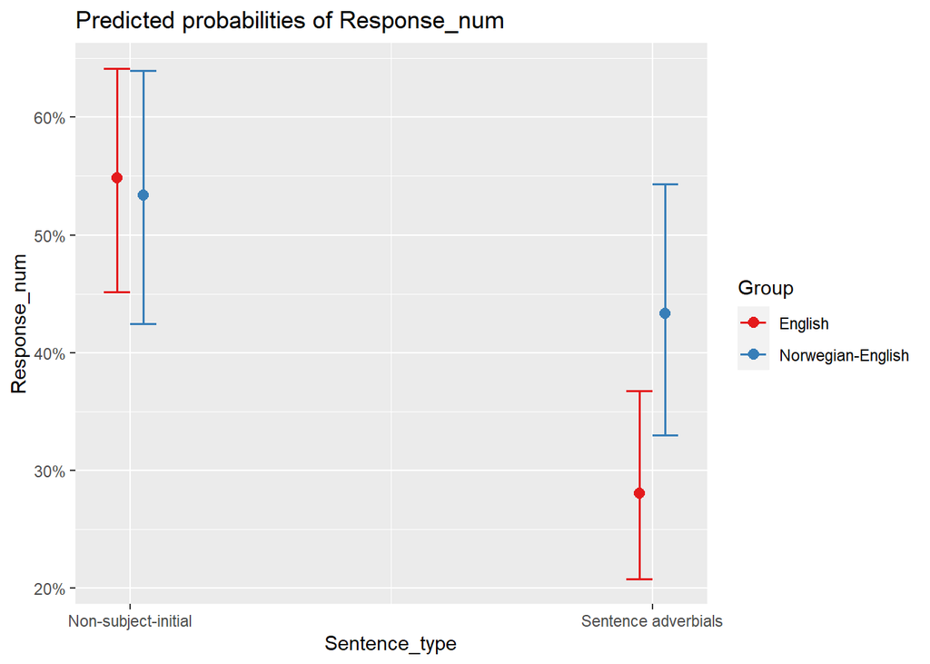

```r
sjPlot::plot_model(m1, type = "pred", terms = c("Sentence_type", "Group"))
```

Show other significant interaction and modify plot.

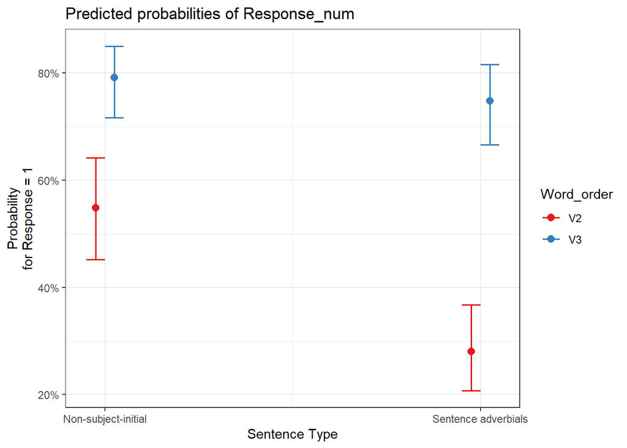

```r
sjPlot::plot_model(m1, type = "pred", terms = c("Sentence_type", "Word_order"))  +
  ggplot2::theme_bw() +
  ggplot2::labs(x = "Sentence Type", y = "Probability\nfor Response = 1")
```

# Wrap-up

That’s all folks!

# Citation & Session Info

Schweinberger, Martin. 2022. *Introduction to Data Visualization with R - AcqVA Aurora workshop*. Tromsø: The Arctic University of Norway, Tromsø. url: https://slcladal.github.io/introviz.html (Version 2022.01.26).

```
@manual{schweinberger2022acqvavizrws,
  author = {Schweinberger, Martin},
  title = {Introduction to Data Visualization with R - AcqVA Aurora workshop},
  note = {https://slcladal.github.io/introviz.html},
  year = {2022},
  organization = "The Arctic University of Norway (UiT), AcqVA Aurora Center},
  address = {Tromsø},
  edition = {2022.01.26}
}
```

Back to top

# References

Bryer, Jason, and Kimberly Speerschneider. 2016. *Likert: Analysis and Visualization Likert Items*. https://CRAN.R-project.org/package=likert.

Meyer, David, Achim Zeileis, and Kurt Hornik. 2021. “Vcd: Visualizing Categorical Data. R Package Version 1.4-9.”

Wickham, Hadley. 2016. *Ggplot2: Elegant Graphics for Data Analysis*. Springer-Verlag New York. https://ggplot2.tidyverse.org.

Wilkinson, Leland. 2012. “The Grammar of Graphics.” In *Handbook of Computational Statistics. Concepts and Methods*, edited by James E. Gentle, Wolfgang Karl H, and Yuichi Mori, 375–414. Springer.

Zeileis, Achim, David Meyer, and Kurt Hornik. 2007. “Residual-Based Shadings for Visualizing (Conditional) Independence.” *Journal of Computational and Graphical Statistics*.